# TS analysis

2023-05-06

# Preprocessing

```r
library(tidyverse)
library(readxl)
library(forecast)
library(tseries)
ibtl <- read_excel("data/IB TL Data.xlsx")
```

```r
ibtl <- ibtl %>%
  mutate(yearmonth = paste0(`Ship Year`, "-",`Ship Month`,"-01")) %>%
  mutate(date = as.Date(yearmonth))

all_ship <- ibtl %>%
  group_by(date) %>%
  summarize(total_count = sum(`Shipment Count`))

ship_series <- ts(all_ship$total_count, frequency=12, start=c(2019,11))
```

# Exploratory Analysis

We aim to use Autoregressive Integrated Moving Average (ARIMA) models to depict the shipment time series. ARIMA models are defined for stationary time series. Therefore, we need to check stationarity before constructing models:

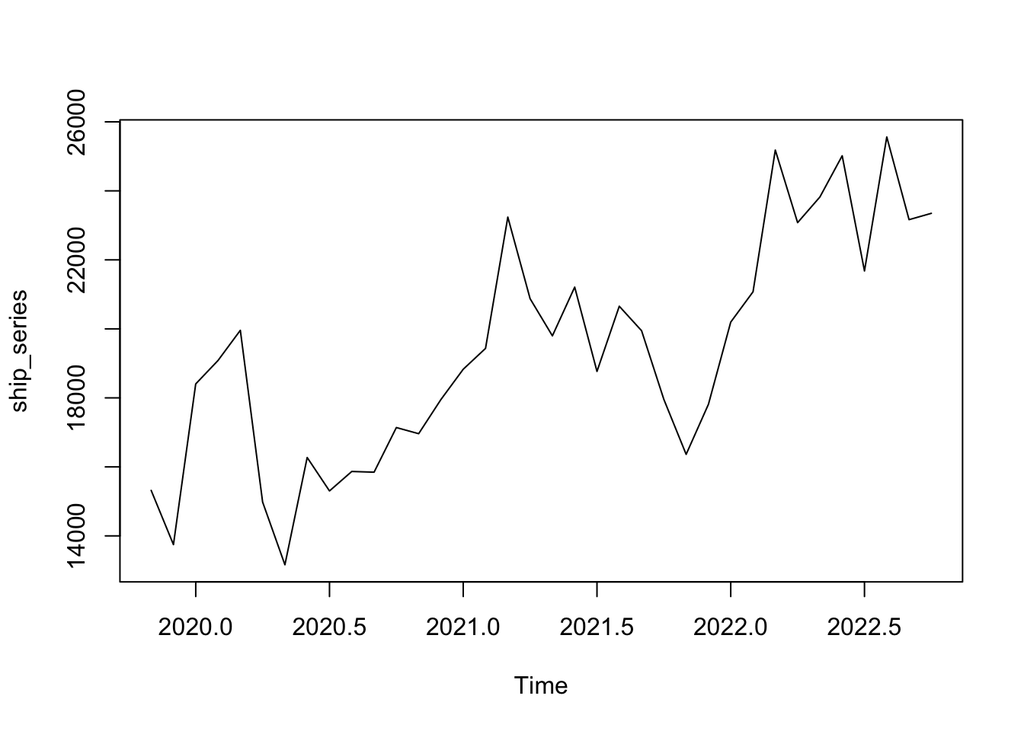

```r
plot.ts(ship_series)
```

From the time series plot we can see that overall there is upward trend in shipment from November of 2019 to October of 2022. No seasonality can be detected from the plot. However, the series does not show stationarity, so we need to difference:

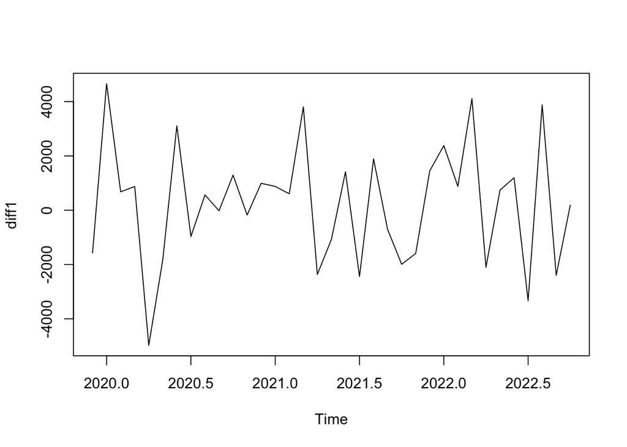

```r
diff1 <- diff(ship_series, differences=1)
plot.ts(diff1)
```

The resulting time series of first differences (above) gives us a stationary time series. However, a formal test, Augmented Dickey-Fuller Test can also be applied to illustrate stationarity:

```r
adf.test(diff1)
```

```
##
##  Augmented Dickey-Fuller Test
##
## data:  diff1
## Dickey-Fuller = -4.539, Lag order = 3, p-value = 0.01
## alternative hypothesis: stationary
```

We reject the null hypothesis because the p-value is smaller than 0.05. This indicates that the time series is stationary. To put it another way, the first difference does not have time-dependent structure and thus exhibits constant variance over time.

# Select ARIMA Models

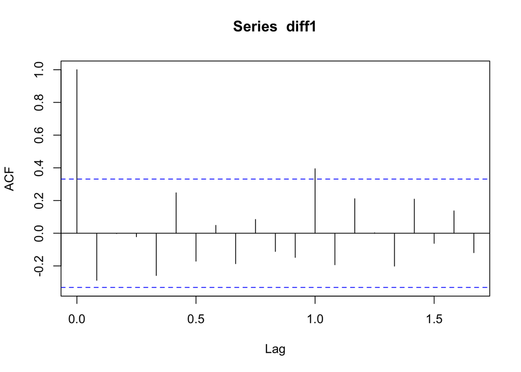

```r
acf(diff1, lag.max=20)
```

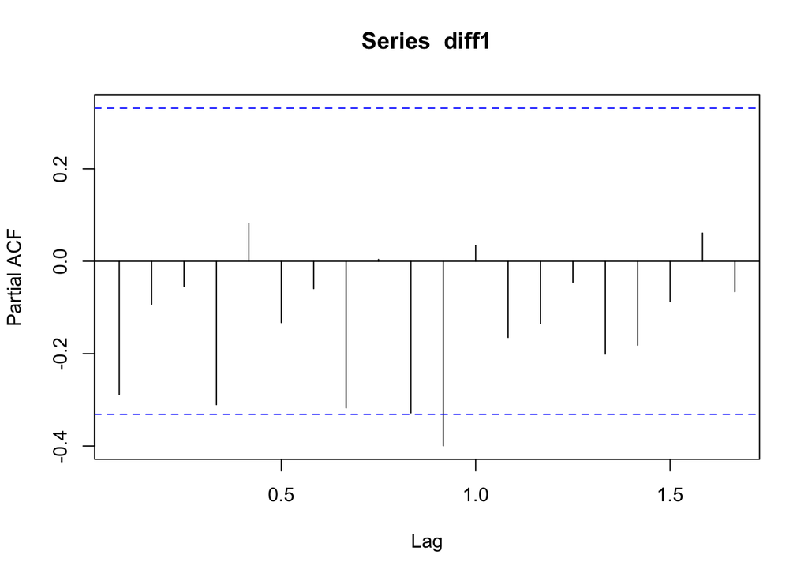

```r
pacf(diff1, lag.max=20)
```

```r
shipseriesarima <- Arima(ship_series, order = c(0,1,0))
summary(shipseriesarima)
```

```
## Series: ship_series
## ARIMA(0,1,0)
##
## sigma^2 = 4907915:  log likelihood = -319.27
## AIC=640.55   AICc=640.67   BIC=642.1
##
## Training set error measures:
##                    ME     RMSE      MAE       MPE     MAPE      MASE       ACF1
## Training set 223.5088 2184.396 1753.842 0.5088851 9.118834 0.5790328 -0.2858676
```

# Forecasting

Now we can use the ARIMA model to forecast the shipment count in the following 5 months:

```r
shiptimeseriesforecasts <- forecast::forecast(shipseriesarima, h=5)
shiptimeseriesforecasts
```

```
##          Point Forecast    Lo 80    Hi 80    Lo 95    Hi 95
## Nov 2022          23349 20509.87 26188.13 19006.93 27691.07
## Dec 2022          23349 19333.87 27364.13 17208.39 29489.61
## Jan 2023          23349 18431.49 28266.51 15828.32 30869.68
## Feb 2023          23349 17670.75 29027.25 14664.86 32033.14
## Mar 2023          23349 17000.52 29697.48 13639.84 33058.16
```

We can plot the original time series, and the forecasted values as below:

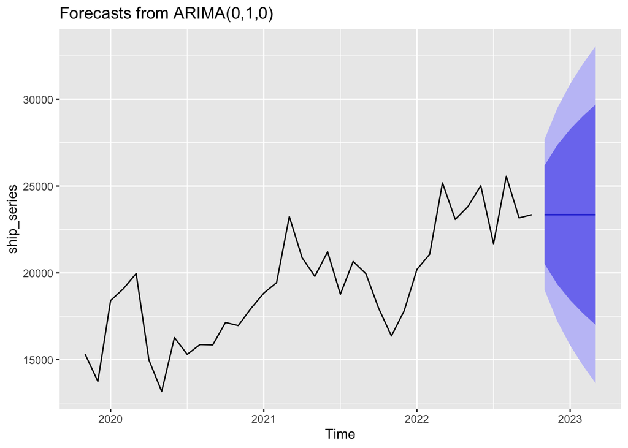

```r
autoplot(shiptimeseriesforecasts)
```